# Walk-forward performance

S&P 500 network momentum · annual expanding WFO · 2019–2025

**Research proxy with 2 unavailable portfolio dates.** Equity and drawdown stop at each gap and restart at 100. A continuous seven-year equity curve and full-period maximum drawdown remain unavailable.

**Held-valuation repair:** 1,758 of 1,760 days and 82 of 84 months are complete. Forecasts and models are frozen. The remaining unavailable dates involve non-tradeable contingent rights.

## Remaining contingent-right sensitivity

The ranges below vary the rights mark from zero to the contractual maximum, accounting for the position's sign. They are hypothetical one-day valuations, with no assumed sale or subsequent rights accounting. They do not certify continuous wealth or realized liquidation.

| Stock | Unresolved date | GMOM lower one-day mark | GMOM upper one-day mark | Range (portfolio bps) |
| --- | --- | --- | --- | --- |
| ABMD | 2022-12-22 | -0.03224% | -0.02845% | 0.380 |
| WBA | 2025-08-28 | -0.12456% | -0.06563% | 5.893 |

## Daily performance statistics

| strategy | Annualized mean* | Annualized vol* | Sharpe* | Sortino* | Positive days* | Worst 5% mean* | Worst day* | Best day* |
| --- | --- | --- | --- | --- | --- | --- | --- | --- |
| LongOnly | 6.69% | 8.62% | 0.776 | 1.076 | 54.61% | -1.31% | -3.50% | 3.15% |
| MACD | -0.48% | 3.11% | -0.153 | -0.202 | 52.84% | -0.51% | -1.31% | 1.06% |
| LinReg | 6.09% | 8.09% | 0.753 | 1.045 | 54.44% | -1.23% | -3.48% | 3.14% |
| GMOM | 5.84% | 7.94% | 0.736 | 1.019 | 54.38% | -1.22% | -3.50% | 3.14% |
| RegCombo | 5.69% | 7.79% | 0.731 | 1.014 | 54.21% | -1.19% | -3.49% | 3.12% |
| SignCombo | 5.97% | 8.00% | 0.745 | 1.033 | 54.32% | -1.22% | -3.49% | 3.14% |

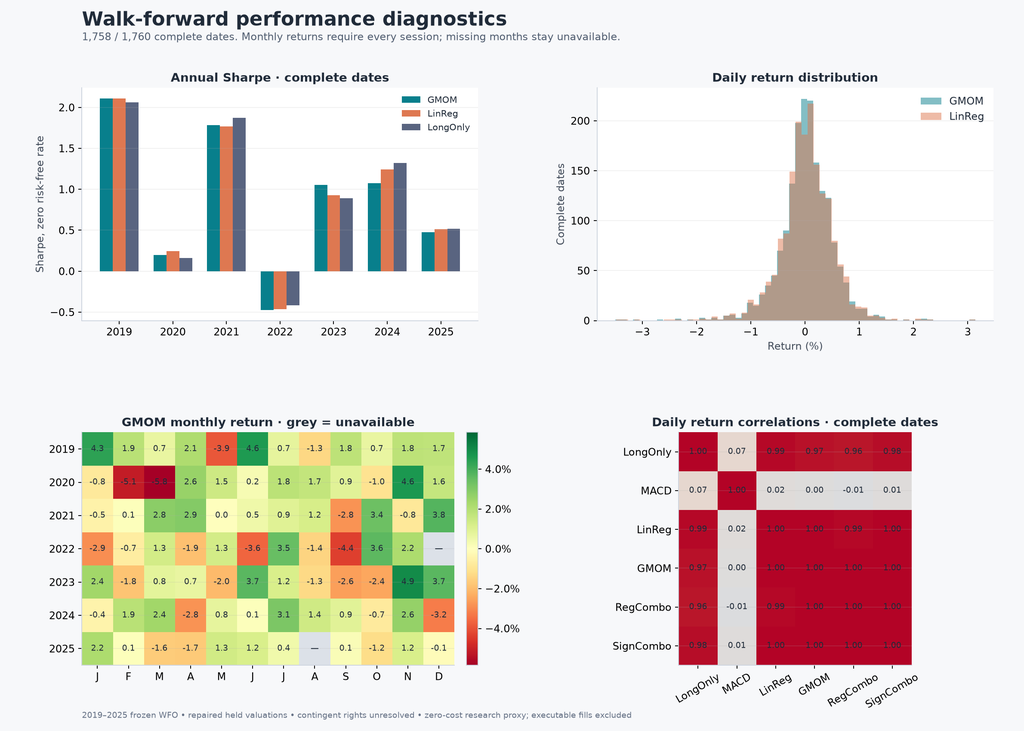

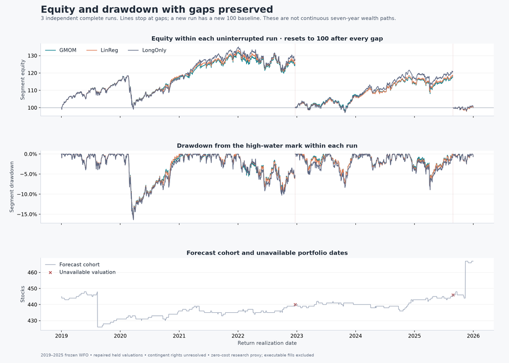

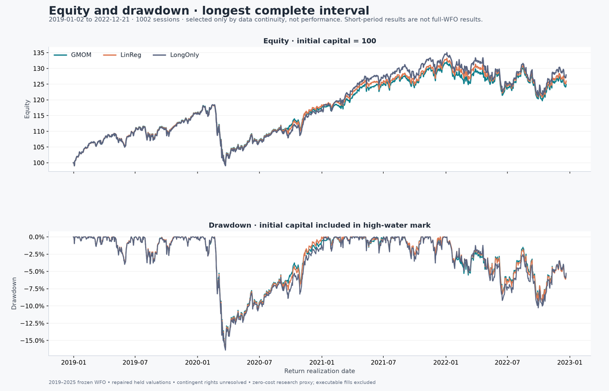

## Longest complete interval: 2019-01-02 to 2022-12-21

| strategy | Interval return | Interval max drawdown | Positive days |
| --- | --- | --- | --- |
| LongOnly | 27.96% | -16.40% | 55.49% |
| MACD | -3.57% | -6.09% | 53.79% |
| LinReg | 26.00% | -16.18% | 55.29% |
| GMOM | 24.88% | -16.05% | 55.19% |
| RegCombo | 25.09% | -15.93% | 55.09% |
| SignCombo | 25.44% | -16.12% | 55.19% |

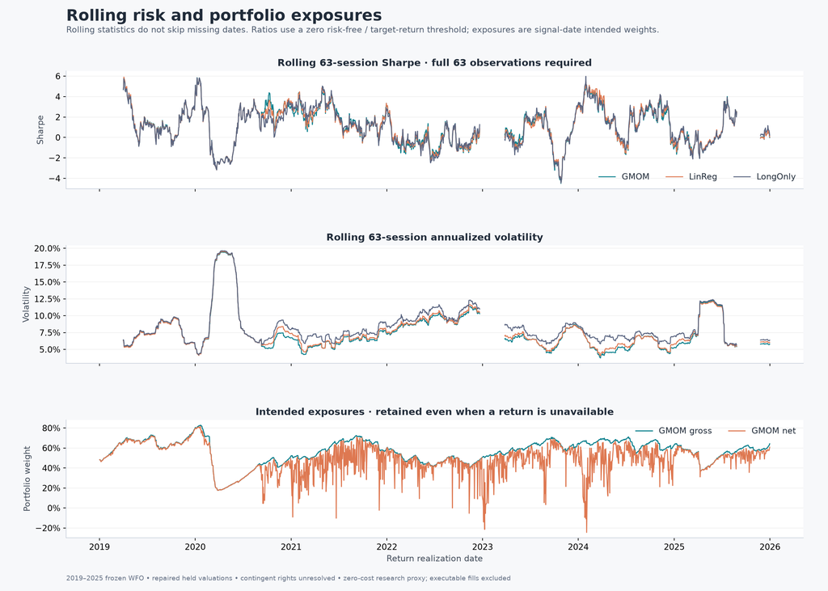

## Definitions and interpretation

- *Complete-date statistics describe 1,758 observed dates out of 1,760, conditional on availability. They are not a continuous seven-year performance record.
- The 2 incomplete dates and all forecasts remain saved. No missing return is filled or reweighted away. Equity and drawdown restart at each uninterrupted run; cross-gap CAGR, total return, maximum drawdown, Calmar and recovery duration remain withheld.
- Sortino = sqrt(252) × mean daily return / sqrt(mean(min(return, 0)²)); zero threshold. Sharpe uses sample daily volatility and zero risk-free rate. Annualized mean = 252 × daily arithmetic mean, not CAGR.
- Positive-day fraction includes zero-return days in its denominator. Worst 5% mean averages the worst ceil(0.05 × observed days) returns. These are portfolio-day statistics, not trade win rates or trade profit factors.
- Monthly compounded returns require every scheduled session to be observed. Rolling 63-session statistics require all 63 returns and stay unavailable across gaps. Intended exposures use all signal dates, including unavailable valuation dates.
- LongOnly is an inverse-volatility-sized matched cohort, not the capital-weighted S&P 500. Trading costs, financing, borrow, executable fills and complete terminal/corporate-action cash flows are not included.
- This report uses a retrospective realized-label overlay on frozen original forecasts. Sixty unavailable stock/date valuations were recovered: 30 SIP quotes, three predecessor-symbol quotes, and 27 fixed cash/share merger entitlements. Raw prices and original WFO outputs remain unchanged.
- ABMD on 2022-12-22 and WBA on 2025-08-28 remain unavailable because their consideration includes non-tradeable contingent rights. Their face-value versus zero-mark sensitivity is saved separately; neither assumption is substituted into these primary returns.
- Models, networks, scalers, hyperparameters, positions, cohorts, and original observed labels are unchanged. Original feature/eligibility gaps and training-label limitations are retained; this is an accounting correction of the saved experiment, not a refitted clean-data backtest.
- Merger entitlements use contemporaneous raw USD acquirer closes and final closing terms. Cash/share receivables are marked without settlement friction. Source close-to-close entries may be stale or untradeable around completion; executable trading and subsequent contingent-right accounting remain unmodeled.
- Three predecessor quotes were transcribed from source tables with matching controls. Unchanged adjustment-scale brackets on absent bars are a reviewed continuity assumption, not a separately complete corporate-action feed.